# Predicting Housing Prices in Mecklenberg County, NC

Aidan Rhianne & Chris Michael

September 21, 2022

# A. Introduction

### The Purpose of Predicting Housing Prices

The residential housing market contributes to nearly 5% of the overall GDP in the U.S. With the ongoing ‘Pandemic Housing Boom’ and the rise in the number of homeowners in the country, market-place companies like Zillow rely on housing price prediction to drive real estate efficiency. Housing prices are directly related to the number of renters, home-owners, and overall economy of a place. Housing price prediction can help developers determine the selling price of homes, as well as help potential buyers plan out their purchase. Predicting home prices, however, is a multifaceted process that depends on:

**i. physical conditions and characteristics of the structure (building materials, facades, architectural style etc.)**  
**ii. location and context (site location, distance from urban amenities, transit etc.)**  
**iii. the demographics of the neighborhood where it is located.**

This projects aims to build a predictive model for home prices in *Mecklenberg County, North Carolina*. This model is loosely based on Zillow’s private estimate, but accounts for the local context, demographics and spatial distribution of urban amenities. Modelling housing prices not only helps plan for future development but also helps visualize how demographic variables like race and income disparities drive clustering of home prices in neighborhoods. This was a difficult exercise in terms of the amount and type of data that was available to us, and choosing which ones could be potential drivers of home prices. Our stratergy was to look at data that we assumed had an effect on where people chose to buy homes- within a well-rated school districts, near transit infrastructure etc.

The major drivers of home prices in Mecklenberg County seem to be internal characteristics of the home- like number of bedrooms, story height etc. We also noticed that proximity to parks and amenities like day care facilities also seemed to have an effect on sales prices. Our final model does have some significant error, which can potentially be attributed to extremely high/low home values that could be skewing the data. The model is, however, fairly generalizable for Mecklenberg County and does better at predicting sales prices of homes in high income areas. With future research, more comprehensive, rigorous version of this model could be recommended as a alternative to the Zillow Zestimate.

# B. The Set-Up

### I. Installing Packages

```r
library(tidyverse)
library(tidycensus)
library(dplyr)
library(sf)
library(kableExtra)
library(RColorBrewer)
library(hrbrthemes)
library(viridis)
library(ggthemes)
library(ggplot2)
library(plotly)
library(scales)
library(extrafont)
library(basetheme)
library(RColorBrewer)
library(lemon)
library(data.table)
library(GGally)
require(gridExtra)
library(ggalt)
library(rgeos)
library(sp)
library(smoothr)
library(rgdal)
library(rgeos)
library(maptools)
library(ggmap)
library(scales)
library(ggeasy)
library("wesanderson")
library(spdep)
library(caret)
library(ckanr)
library(FNN)
library(grid)
library(ggcorrplot)
library(corrr)
library(kableExtra)
library(jtools)
library(ggstance)
library(ggpubr)
library(broom.mixed)
library(tab)
library(sjPlot)
library(plotly)
library(stargazer)

col <- wes_palette("Royal1")
col5 <- colorRampPalette(col)(5)
col6 <- colorRampPalette(col)(6)
col7 <- colorRampPalette(col)(7)
col8 <- colorRampPalette(col)(8)
col10 <- colorRampPalette(col)(10)
col29 <- colorRampPalette(col)(29)

options(scipen = 999)
options(tigris_class = "sf")

source("https://raw.githubusercontent.com/urbanSpatial/Public-Policy-Analytics-Landing/master/functions.r")
```

We started creating the markdown by installing the required packages and loading them into the library. Some of the mainly used packages are `tidyverse`, `tidycensus`, and `dplyr`. The final deliverable for this homework is an RMarkdown file with the required plots and tables, knitted to a HTML document.

# C. Talking about the Data

### I. American Community Survey (2019)

We pulled data from the 2019 5-year American Community Survey (ACS) from the U.S Census Bureau. The selected geography includes the 233 tracts in Mecklenberg County, North Carolina. The variables we looked at were **total population**, **median household income**, and **percent of population with a bachelors degree**. We wanted to take a look at whether factors like income and education had an effect on housing prices in a locality, and the extent of its influence.

```r
tracts19 <-
  get_acs(geography = "tract",
          variables = c("B01001_001E", "B19013_001E", "B15001_050E", "B15001_009E"),
          year=2019, state=37, county=119,
          geometry=TRUE, output="wide") %>%
  rename(TotalPop = B01001_001E,
         MedHHInc = B19013_001E,
         FBachelor = B15001_050E,
         MBachelor = B15001_009E) %>%
  dplyr::select(-NAME, -starts_with("B")) %>%
  mutate(pctBachelors = ifelse(TotalPop > 0, ((FBachelor + MBachelor) / TotalPop),0)) %>%
  dplyr::select(-FBachelor, -MBachelor, TotalPop)
```

### II. Housing Data (Student Data)

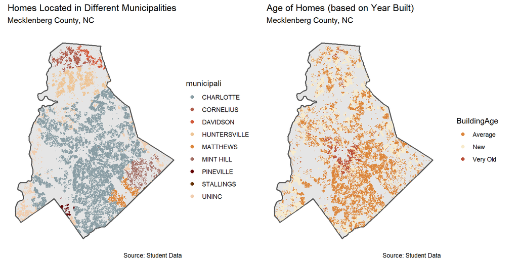

```r
MKLB <- st_read("C:/Users/Chris Michael/Desktop/UPenn/Fall 2022/508/MUSA_508_Lab-main/MUSA_508_Lab-main/Midterm/data/2022/studentData.geojson") %>%
  st_transform(st_crs(tracts19)) %>%
  dplyr::mutate(BldAge = case_when(yearbuilt >= 0 & yearbuilt <= 1940 ~ 1, # very old
                            yearbuilt > 1940 & yearbuilt <= 2000 ~ 2, # average
                            yearbuilt > 2000 & yearbuilt <= 2022 ~ 3)) %>%
  mutate(BuildingAge = case_when(yearbuilt >= 0 & yearbuilt <= 1940 ~ "Very Old",
                            yearbuilt > 1940 & yearbuilt <= 2000 ~ "Average",
                            yearbuilt > 2000 & yearbuilt <= 2022 ~ "New")) %>%
  mutate(BldStry = case_when(storyheigh == "1 STORY" ~ 1,
                             storyheigh == "1.5 STORY" ~ 1,
                             storyheigh == "2.0 STORY" ~ 2,
                             storyheigh == "2.5 STORY" ~ 2,
                             storyheigh == "BI-LEVEL" ~ 2,
                             storyheigh == "SPLIT LEVEL" ~ 2,
                             storyheigh == "RANCH W/BSMT" ~ 2,
                             storyheigh == "3.0 STORY" ~ 3,
                             storyheigh == "CAPE COD" ~ 3,
                             storyheigh == ">=4.0 STORY" ~ 4)) %>%
  mutate(Fuel = case_when(heatedfuel == "OIL/WD/COAL" ~ 1,
                          heatedfuel == "NONE" ~ 1,
                          heatedfuel == "GAS" ~ 2,
                          heatedfuel == "ELECTRIC" ~ 2,
                          heatedfuel == "SOLAR/GEOTHRM" ~ 3)) %>%
  mutate(BldGrd = case_when(bldggrade == "MINIMUM" ~ 1,
                            bldggrade == "AVERAGE" ~ 2,
                            bldggrade == "CUSTOM" ~ 2,
                            bldggrade == "FAIR" ~ 3,
                            bldggrade == "GOOD" ~ 3,
                            bldggrade == "VERY GOOD" ~ 4,
                            bldggrade == "EXCELLENT" ~ 5)) %>%
  mutate(ExtWall = case_when(extwall == "STONE" ~ 3,
                             extwall == "FACE BRICK" ~ 2,
                             extwall == "CONC BLOCK" ~ 1)) %>%
  mutate(ZIP = case_when(zipcode == 27619 ~ 1)) %>%
  mutate(HUNTERSVILLE = case_when(municipali == "HUNTERSVILLE" ~ 1)) %>%
  mutate(CORNELIUS = case_when(municipali == "CORNELIUS" ~ 1)) %>%
  mutate(DAVIDSON = case_when(municipali == "DAVIDSON" ~ 1)) %>%
  mutate(CHARLOTTE = case_when(municipali == "CHARLOTTE" ~ 1)) %>%
  mutate(MINTHILL = case_when(municipali == "MINT HILL" ~ 1)) %>%
  mutate(MATTHEWS = case_when(municipali == "MATTHEWS" ~ 1)) %>%
  mutate(PINEVILLE = case_when(municipali == "PINEVILLE" ~ 1)) %>%
  mutate(UNINC = case_when(municipali == "UNINC" ~ 1)) %>%
  mutate(STALLINGS = case_when(municipali == "STALLINGS" ~ 1)) %>%
  mutate_at(c('ExtWall','ZIP','HUNTERSVILLE','CORNELIUS','DAVIDSON',
              'CHARLOTTE','MINTHILL','MATTHEWS','PINEVILLE','UNINC','STALLINGS'), ~replace_na(.,0))

A <- ggplot() +
  geom_sf(data=st_union(tracts19),size=0.75) +
  geom_sf(data=MKLB, aes(color=municipali), size=0.25) +
  geom_sf(data=st_union(tracts19),fill=NA) +
  scale_color_manual(values = c("#899da4","#af5d4c","#d25838",
                                "#eec494","#dc863b","#a46f65","#660000",
                                "#663300","#f1cdae"))+
  labs(title="Homes Located in Different Municipalities",
       subtitle="Mecklenberg County, NC\n",
       caption="Source: Student Data") +
  theme_void()+
  guides(color = guide_legend(override.aes = list(size = 2)))

B <- ggplot() +
  geom_sf(data=st_union(tracts19),size=0.75) +
  geom_sf(data=MKLB, aes(color=BuildingAge), size=0.25) +
  geom_sf(data=st_union(tracts19),fill=NA) +
  scale_color_manual(values = c("#dc863b","#f8ebcb","#b94d36"))+
  labs(title="Age of Homes (based on Year Built)",
       subtitle="Mecklenberg County, NC\n",
       caption="Source: Student Data") +
  theme_void()+
  guides(color = guide_legend(override.aes = list(size = 2)))

ggarrange(A,B, align = "v")
```

### III. Transit Data

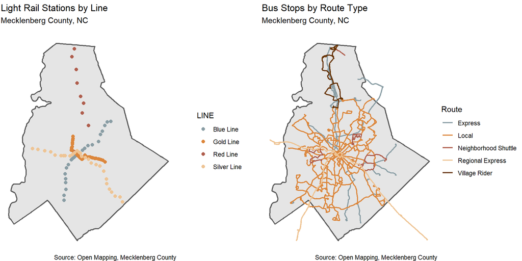

```r
Blue_Stations <- st_read("C:/Users/Chris Michael/Desktop/UPenn/Fall 2022/508/MUSA_508_Lab-main/MUSA_508_Lab-main/Midterm/lynxblueline_station") %>%
  dplyr::mutate(LINE = "Blue Line") %>%
  select(LINE, geometry)

Gold_Stations <- st_read("C:/Users/Chris Michael/Desktop/UPenn/Fall 2022/508/MUSA_508_Lab-main/MUSA_508_Lab-main/Midterm/lynxgoldline_station")%>%
  dplyr::mutate(LINE = "Gold Line") %>%
  select(LINE, geometry)

Red_Stations <- st_read("C:/Users/Chris Michael/Desktop/UPenn/Fall 2022/508/MUSA_508_Lab-main/MUSA_508_Lab-main/Midterm/lynxredline_station")%>%
  dplyr::mutate(LINE = "Red Line") %>%
  select(LINE, geometry)

Silver_Stations <- st_read("C:/Users/Chris Michael/Desktop/UPenn/Fall 2022/508/MUSA_508_Lab-main/MUSA_508_Lab-main/Midterm/lynxsilverline_station")%>%
  dplyr::mutate(LINE = "Silver Line") %>%
  select(LINE, geometry)

Stations <- rbind(Blue_Stations, Gold_Stations, Red_Stations, Silver_Stations)

Stations_Buffers <-
  rbind(st_buffer(Stations, 2640) %>%
      mutate(Legend = "Buffer") %>%
      dplyr::select(Legend),
    st_union(st_buffer(Stations, 2640)) %>%
      st_sf() %>%
      mutate(Legend = "Unioned Buffer"))%>%
  st_transform(st_crs(tracts19))

buffer <- filter(Stations_Buffers, Legend=="Unioned Buffer")

tracts19 <-
  rbind(st_centroid(tracts19)[buffer,] %>%
      st_drop_geometry() %>%
      left_join(tracts19) %>%
      st_sf() %>%
      mutate(TOD = 1),
    st_centroid(tracts19)[buffer, op = st_disjoint] %>%
      st_drop_geometry() %>%
      left_join(tracts19) %>%
      st_sf() %>%
      mutate(TOD = 0))%>%
  st_transform(st_crs(tracts19))

sf::sf_use_s2(FALSE)
MKLB <- st_join(MKLB, tracts19, by=geometry)

MKLB <-
  MKLB %>%
  st_as_sf(coords = c("Longitude", "Latitude"), crs = 4326, agr = "constant") %>%
  st_transform('EPSG:2264')

bus_stops <- st_read ("C:/Users/Chris Michael/Desktop/UPenn/Fall 2022/508/MUSA_508_Lab-main/MUSA_508_Lab-main/Midterm/cats_busroutes")%>%
  st_transform(st_crs(MKLB)) %>%
  select(geometry)

MKLB$BusStopBuffer <- MKLB%>%
    st_buffer(5280) %>%
    stats::aggregate(mutate(bus_stops, counter = 1),., sum) %>%
    pull(counter)

MKLB["BusStopBuffer"][is.na(MKLB["BusStopBuffer"])] <- 0

Silver_Stations_p <- st_read("C:/Users/Chris Michael/Desktop/UPenn/Fall 2022/508/MUSA_508_Lab-main/MUSA_508_Lab-main/Midterm/lynxsilverline_station")%>%
  dplyr::mutate(LINE = "Silver Line")

Silver_Stations_p <- subset(Silver_Stations_p, Name!="Belmont" & Name!="Stallings" &
                              Name!="Indian Trail") %>%
  select(LINE, geometry)

Stations_plot <- rbind(Blue_Stations, Gold_Stations, Red_Stations, Silver_Stations_p)%>%
  st_transform(st_crs(tracts19)) %>%
  st_crop(tracts19)

C <- ggplot() +
  geom_sf(data=st_union(tracts19),size=0.75) +
  geom_sf(data=Stations_plot, aes(color=LINE), size=2) +
  scale_color_manual(values = c("#899da4","#dc863b","#af5d4c","#eec494"))+
  labs(title="Light Rail Stations by Line",
       subtitle="Mecklenberg County, NC\n",
       caption="Source: Open Mapping, Mecklenberg County") +
  theme_void()

bus_stops_p <- st_read ("C:/Users/Chris Michael/Desktop/UPenn/Fall 2022/508/MUSA_508_Lab-main/MUSA_508_Lab-main/Midterm/cats_busroutes")%>%
  rename(Route = ROUTE_TYPE) %>%
  st_transform(st_crs(tracts19))  %>%
  st_crop(tracts19)

D <- ggplot() +
  geom_sf(data=st_union(tracts19),size=0.75) +
  geom_sf(data=bus_stops_p, aes(color=Route), size=0.75) +
  scale_color_manual(values = c("#899da4","#dc863b","#af5d4c","#eec494","#663300"))+
  labs(title="Bus Stops by Route Type",
       subtitle="Mecklenberg County, NC\n",
       caption="Source: Open Mapping, Mecklenberg County") +
  theme_void()

ggarrange(C,D, align = "v")
```

### III. Open Data

Most of the data in this section was obtained from the Mecklenberg County Open Mapping website. We used the `buffer` function, as well as `k-nearest-neighbors` to determine the spatial clustering of urban amenities near homes. We chose the data based on what we assumed make certain homes more attractive to buyers- like the presence of **open green spaces**, **schools** and **day care centers**. It was also interesting to look at how factors like the proximity to waste disposal centers affected home prices and thereby the willingness to purchase a home in the area.

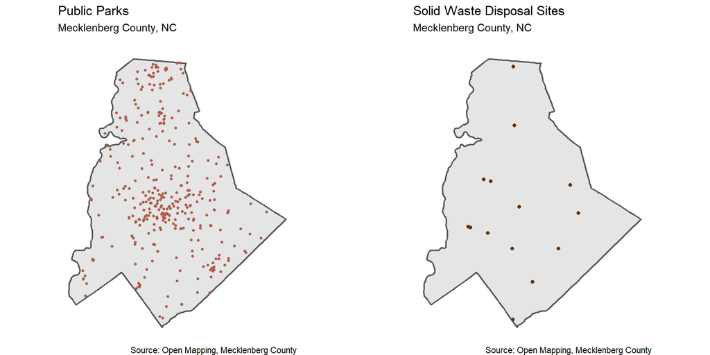

```r
park <- st_read ("C:/Users/Chris Michael/Desktop/UPenn/Fall 2022/508/MUSA_508_Lab-main/MUSA_508_Lab-main/Midterm/park_locations")%>%
  st_transform(st_crs(MKLB)) %>%
  select(geometry)

MKLB$ParkBuffer <- MKLB%>%
    st_buffer(18480) %>% # 3.5 miles (distance with no NAs)
    stats::aggregate(mutate(park, counter = 1),., sum) %>%
    pull(counter)

swaste <- st_read ("C:/Users/Chris Michael/Desktop/UPenn/Fall 2022/508/MUSA_508_Lab-main/MUSA_508_Lab-main/Midterm/solidwaste_facility")%>%
  st_transform(st_crs(MKLB)) %>%
  select(geometry)

MKLB$WasteBuffer <- MKLB%>%
    st_buffer(10560) %>% # 3.5 miles (distance with no NAs)
    stats::aggregate(mutate(swaste, counter = 1),., sum) %>%
    pull(counter)

MKLB["WasteBuffer"][is.na(MKLB["WasteBuffer"])] <- 0

daycare <- st_read("C:/Users/Chris Michael/Desktop/UPenn/Fall 2022/508/MUSA_508_Lab-main/MUSA_508_Lab-main/Midterm/daycare") %>%
  dplyr::select(flzip, geometry) %>%
    st_as_sf(coords = c("Long", "Lat"), crs = 4326, agr = "constant") %>%
    st_transform('EPSG:2264') %>%
    distinct()

MKLB <- MKLB %>% mutate(daycare_nn1 = nn_function(st_coordinates(MKLB),
                              st_coordinates(daycare), k = 1),
                  daycare_nn2 = nn_function(st_coordinates(MKLB),
                              st_coordinates(daycare), k = 2),
                  daycare_nn3 = nn_function(st_coordinates(MKLB),
                              st_coordinates(daycare), k = 3),
                  daycare_nn4 = nn_function(st_coordinates(MKLB),
                              st_coordinates(daycare), k = 4),
                  daycare_nn5 = nn_function(st_coordinates(MKLB),
                              st_coordinates(daycare), k = 5))

libraries <- st_read("C:/Users/Chris Michael/Desktop/UPenn/Fall 2022/508/MUSA_508_Lab-main/MUSA_508_Lab-main/Midterm/library") %>%
  dplyr::select(Name, Zip, geometry) %>%
    st_as_sf(coords = c("Long", "Lat"), crs = 4326, agr = "constant") %>%
    st_transform('EPSG:2264') %>%
    distinct()

MKLB <-MKLB %>%  mutate(Lib_nn1 = nn_function(st_coordinates(MKLB),
                              st_coordinates(libraries), k = 1),
                        Lib_nn2 = nn_function(st_coordinates(MKLB),
                              st_coordinates(libraries), k = 2),
                        Lib_nn3 = nn_function(st_coordinates(MKLB),
                              st_coordinates(libraries), k = 3),
                        Lib_nn4 = nn_function(st_coordinates(MKLB),
                              st_coordinates(libraries), k = 4),
                        Lib_nn5 = nn_function(st_coordinates(MKLB),
                              st_coordinates(libraries), k = 5))

schools <- st_read("C:/Users/Chris Michael/Desktop/UPenn/Fall 2022/508/MUSA_508_Lab-main/MUSA_508_Lab-main/Midterm/cms_schools") %>%
  dplyr::select(school_num, school, zipcode, geometry) %>%
    st_as_sf(coords = c("Long", "Lat"), crs = 4326, agr = "constant") %>%
    st_transform('EPSG:2264') %>%
    distinct()

MKLB <- MKLB %>% mutate(School_nn1 = nn_function(st_coordinates(MKLB),
                              st_coordinates(schools), k = 1),
                        School_nn2 = nn_function(st_coordinates(MKLB),
                              st_coordinates(schools), k = 2),
                        School_nn3 = nn_function(st_coordinates(MKLB),
                              st_coordinates(schools), k = 3),
                        School_nn4 = nn_function(st_coordinates(MKLB),
                              st_coordinates(schools), k = 4),
                        School_nn5 = nn_function(st_coordinates(MKLB),
                              st_coordinates(schools), k = 5))

AO <- ggplot() +
  geom_sf(data=st_union(tracts19),size=0.75) +
  geom_sf(data=park, aes(color="#899da4"), size=1, show.legend = FALSE) +
  scale_color_manual(values = c("#af5d4c","#eec494","#663300"))+
  labs(title="Public Parks",
       subtitle="Mecklenberg County, NC\n",
       caption="Source: Open Mapping, Mecklenberg County") +
  theme_void()

BO <- ggplot() +
  geom_sf(data=st_union(tracts19),size=0.75) +
  geom_sf(data=swaste, aes(color="#899da4"), size=1.5, show.legend = FALSE) +
  scale_color_manual(values = c("#663300"))+
  labs(title="Solid Waste Disposal Sites",
       subtitle="Mecklenberg County, NC\n",
       caption="Source: Open Mapping, Mecklenberg County") +
  theme_void()

ggarrange(AO,BO, align = "v")
```

### IV. Summary Statistics

```r
MKLB_star1 <- MKLB %>%
  dplyr::select("BldAge","BldStry","heatedarea","Fuel","numfirepla","fullbaths",
                "halfbaths","bedrooms","units","BldGrd") %>%
  st_drop_geometry(MKLB_star1)

stargazer(MKLB_star1, type = "html", style = "aer", omit.summary.stat = "n", title="Internal Characteristics of Homes in Mecklenberg County",
  notes.label = 'Notes',
  notes = 'Variables that could potentially have a direct effect on the sales price of homes',
  notes.align = 'l')
```

**Internal Characteristics of Homes in Mecklenberg County**

| Statistic | Mean | St. Dev. | Min | Max |
| --- | --- | --- | --- | --- |
| BldAge | 2.396 | 0.558 | 1 | 3 |
| BldStry | 1.601 | 0.494 | 1 | 4 |
| heatedarea | 2,388.888 | 1,086.296 | 0.000 | 14,710.000 |
| Fuel | 1.993 | 0.085 | 1 | 3 |
| numfirepla | 0.788 | 0.466 | 0 | 7 |
| fullbaths | 2.294 | 0.854 | 0 | 9 |
| halfbaths | 0.595 | 0.533 | 0 | 4 |
| bedrooms | 3.528 | 0.980 | 0 | 65 |
| units | 0.979 | 0.195 | 0 | 8 |
| BldGrd | 2.482 | 0.752 | 1 | 5 |
| Notes | Variables that could potentially have a direct effect on the sales price of homes |  |  |  |

```r
MKLB_star2 <- MKLB %>%
  dplyr::select("TotalPop","MedHHInc","pctBachelors") %>%
  st_drop_geometry(MKLB_star2)

stargazer(MKLB_star2, type = "html", style = "aer", omit.summary.stat = "n", title="Population Demographics in Mecklenberg County",
  notes.label = 'Notes',
  notes = 'Population demographics taken from the 2019 acs for a glimpse of the residents ',
  notes.align = 'l')
```

**Population Demographics in Mecklenberg County**

| Statistic | Mean | St. Dev. | Min | Max |
| --- | --- | --- | --- | --- |
| TotalPop | 5,471.177 | 2,006.218 | 669 | 10,828 |
| MedHHInc | 83,184.490 | 35,565.040 | 16,615 | 244,539 |
| pctBachelors | 0.012 | 0.013 | 0.000 | 0.210 |
| Notes | Population demographics taken from the 2019 acs for a glimpse of the residents |  |  |  |

```r
MKLB_star3 <- MKLB %>%
  dplyr::select("TOD","BusStopBuffer","ParkBuffer","WasteBuffer") %>%
  st_drop_geometry(MKLB_star3)

stargazer(MKLB_star3, type = "html", style = "aer", omit.summary.stat = "n", title="Public Amenities close to Mecklenberg County",
  notes.label = 'Notes',
  notes = 'Variables that show the number of public amenities within a certain distance',
  notes.align = 'l')
```

**Public Amenities close to Mecklenberg County**

| Statistic | Mean | St. Dev. | Min | Max |
| --- | --- | --- | --- | --- |
| TOD | 0.067 | 0.251 | 0 | 1 |
| BusStopBuffer | 3.270 | 3.964 | 0 | 40 |
| ParkBuffer | 26.473 | 20.991 | 3 | 95 |
| WasteBuffer | 0.325 | 0.502 | 0 | 3 |
| Notes | Variables that show the number of public amenities within a certain distance |  |  |  |

```r
MKLB_star4 <- MKLB %>%
  dplyr::select("School_nn1","Lib_nn1","daycare_nn1") %>%
  st_drop_geometry(MKLB_star4)

stargazer(MKLB_star4, type = "html", style = "aer", omit.summary.stat = "n", title="Spatial Clustering of Amenities in Mecklenberg County",
  notes.label = 'Notes',
  notes = 'Variables showing the spatial clustering of amenities around homes in the county',
  notes.align = 'l')
```

**Spatial Clustering of Amenities in Mecklenberg County**

| Statistic | Mean | St. Dev. | Min | Max |
| --- | --- | --- | --- | --- |
| School_nn1 | 4,454.164 | 2,861.795 | 116.992 | 22,481.340 |
| Lib_nn1 | 12,296.840 | 7,068.454 | 242.424 | 34,300.390 |
| daycare_nn1 | 2,991.003 | 2,444.329 | 4.595 | 21,142.780 |
| Notes | Variables showing the spatial clustering of amenities around homes in the county |  |  |  |

# D. The Final Datasets

### I. Challenge, Test & Training Datasets

We split the final dataset into the modelling and the challenge dataset. We also divided the modelling dataset on two- a **training set**; on which we would create our statistical prediction models, and a **test set**; on which we would test our models.

```r
MKLB_modelling<- MKLB %>% filter(toPredict=="MODELLING")
MKLB_challenge <-MKLB %>% filter(toPredict=="CHALLENGE")

set.seed(3456)
MKLB_set = sort(sample(nrow(MKLB_modelling), nrow(MKLB_modelling)*.7))

MKLB_train<-MKLB_modelling[MKLB_set,] %>%
  st_drop_geometry()

MKLB_test<-MKLB_modelling[-MKLB_set,] %>%
  st_drop_geometry()
```

### II. Visualizing the Dependent Variable

The map shows the dependent variable- sales price and the range of its values across the county. It can be observed that a larger portion of the more expensive homes are located in Charlotte- the commercial center, with a few scattered in the northern part of the county. At this stage, it is difficult to talk about what the cause of this distribution might be- but it could be due to higher income residents, who are willing to pay to be close to the urban center and near transit infrastructure.

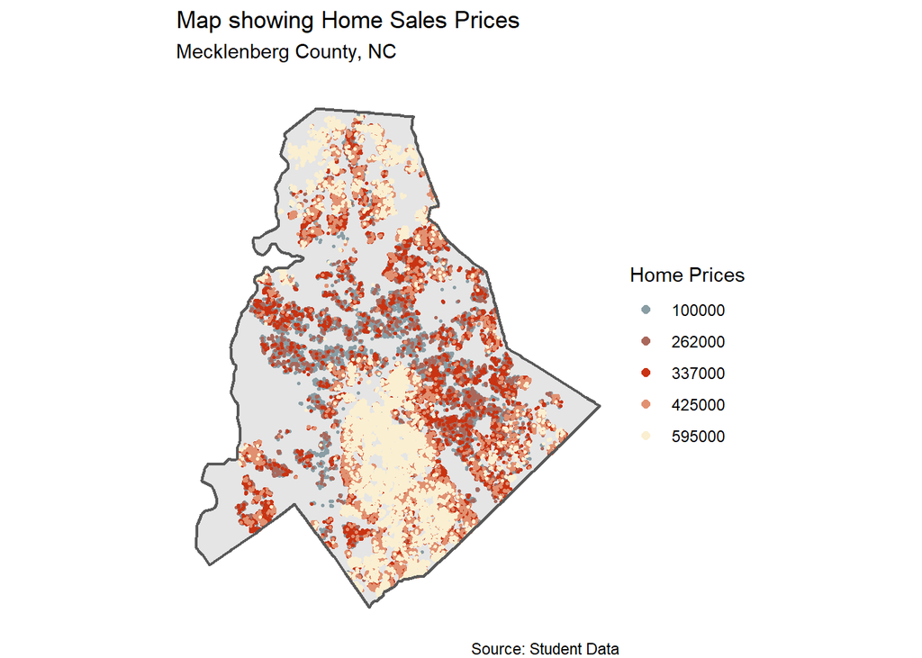

```r
ggplot() +
  geom_sf(data=st_union(tracts19), size=0.75) +
  geom_sf(data=MKLB_modelling, aes(colour = q5(price)), size=0.5) +
  geom_sf(data=st_union(tracts19), fill=NA, size=0.75)+
  scale_color_manual(values = col7,
    labels = qBr(MKLB_modelling, "price"),
                    name = "Home Prices") +
  labs(title="Map showing Home Sales Prices",
       subtitle = "Mecklenberg County, NC\n",
       caption="Source: Student Data") +
    theme_void()+
  guides(color = guide_legend(override.aes = list(size = 2)))
```

### III. Visualizing Independent Variables

This section has a few visualizations of some independent variables that we thought were interested to look at like the presence of **green open spaces** around homes and the **median household income** of the area. We wanted to note the higher number of public parks near the urban center, with fewer designated ‘public’ green spaces as we moved further into the suburbs. It is also interesting to see that a larger portion of wealthier residents seem to be moving into the suburbs as well.

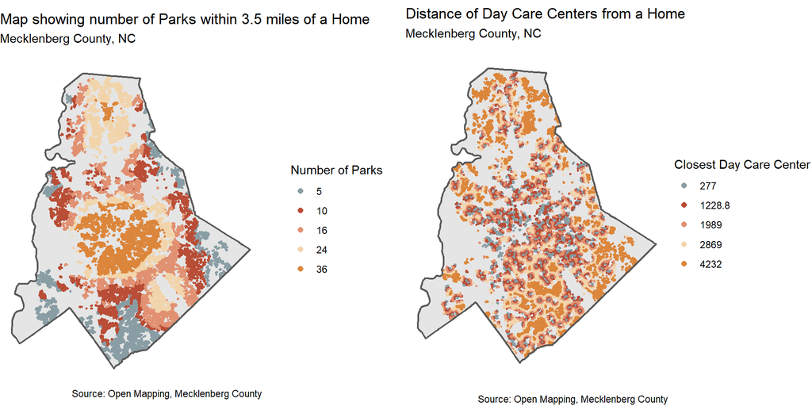

```r
U <- ggplot() +
  geom_sf(data=st_union(tracts19), size=0.75) +
  geom_sf(data=MKLB_modelling, aes(colour = q5(ParkBuffer)), size=0.5) +
  geom_sf(data=st_union(tracts19), fill=NA, size=0.75)+
  scale_color_manual(values = col5,
    labels = qBr(MKLB_modelling, "ParkBuffer"),
                    name = "Number of Parks") +
  labs(title="Map showing number of Parks within 3.5 miles of a Home",
       subtitle = "Mecklenberg County, NC\n",
       caption="Source: Open Mapping, Mecklenberg County") +
    theme_void()+
  guides(color = guide_legend(override.aes = list(size = 2)))

V <- ggplot() +
  geom_sf(data=st_union(tracts19), size=0.75) +
  geom_sf(data=MKLB_modelling, aes(colour = q5(daycare_nn1)), size=0.5) +
  geom_sf(data=st_union(tracts19), fill=NA, size=0.75)+
  scale_color_manual(values = col5,
    labels = qBr(MKLB_modelling, "daycare_nn1"),
                    name = "Closest Day Care Center") +
  labs(title="Distance of Day Care Centers from a Home",
       subtitle = "Mecklenberg County, NC\n",
       caption="\nSource: Open Mapping, Mecklenberg County") +
    theme_void()+
  guides(color = guide_legend(override.aes = list(size = 2)))

ggarrange(U,V, align = "v")
```

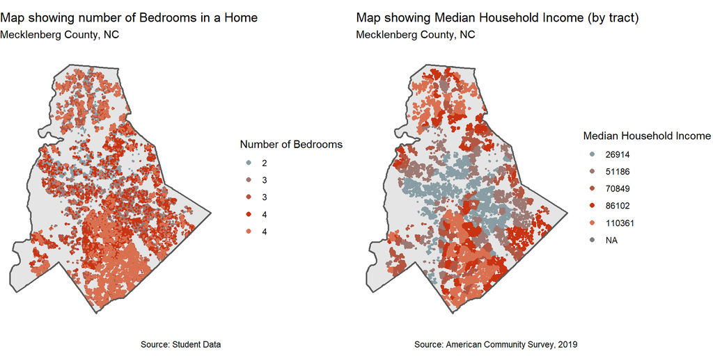

```r
W <- ggplot() +
  geom_sf(data=st_union(tracts19), size=0.75) +
  geom_sf(data=MKLB_modelling, aes(colour = q5(bedrooms)), size=0.5) +
  geom_sf(data=st_union(tracts19), fill=NA, size=0.75)+
  scale_color_manual(values = col10,
    labels = qBr(MKLB_modelling, "bedrooms"),
                    name = "Number of Bedrooms") +
  labs(title="Map showing number of Bedrooms in a Home",
       subtitle = "Mecklenberg County, NC\n",
       caption="\nSource: Student Data") +
    theme_void()+
  guides(color = guide_legend(override.aes = list(size = 2)))

X <- ggplot() +
  geom_sf(data=st_union(tracts19), size=0.75) +
  geom_sf(data=MKLB_modelling, aes(colour = q5(MedHHInc)), size=0.5) +
  geom_sf(data=st_union(tracts19), fill=NA, size=0.75)+
  scale_color_manual(values = col10,
    labels = qBr(MKLB_modelling, "MedHHInc"),
                    name = "Median Household Income") +
  labs(title="Map showing Median Household Income (by tract)",
       subtitle = "Mecklenberg County, NC\n",
       caption="\nSource: American Community Survey, 2019") +
    theme_void()+
  guides(color = guide_legend(override.aes = list(size = 2)))

ggarrange(W,X, align = "v")
```

### IV. Correlation Matrix

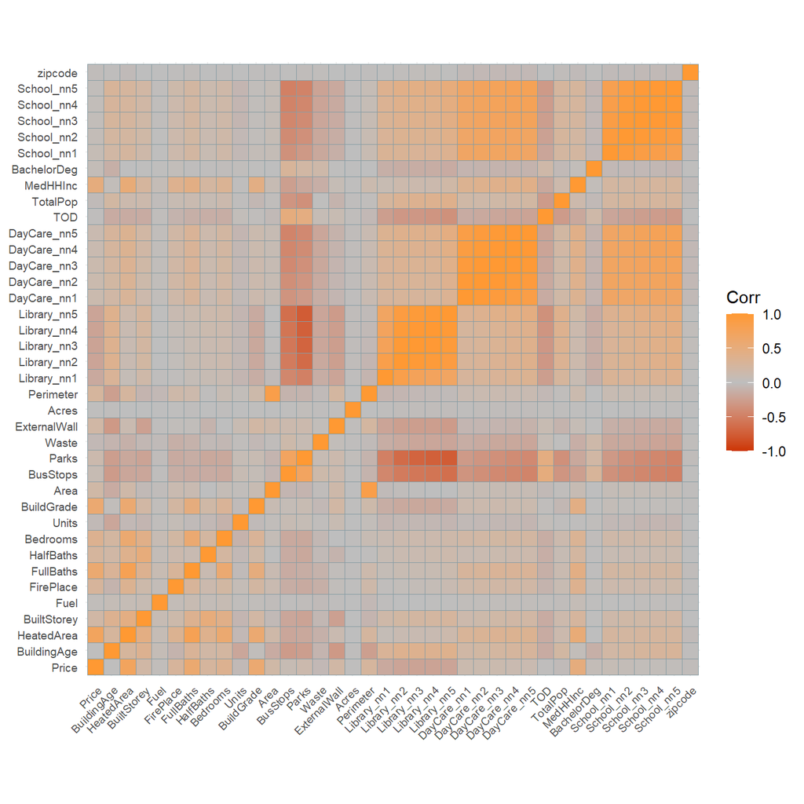

```r
corr <- MKLB_test%>%
  summarise(Price = price,
            BuildingAge = BldAge,
            HeatedArea = heatedarea,
            BuiltStorey = BldStry,
            Fuel = Fuel,
            FirePlace = numfirepla,
            FullBaths = fullbaths,
            HalfBaths = halfbaths,
            Bedrooms = bedrooms,
            Units = units,
            BuildGrade = BldGrd,
            Area = shape_Area,
            BusStops = BusStopBuffer,
            Parks = ParkBuffer,
            Waste = WasteBuffer,
            ExternalWall = ExtWall,
            Acres = totalac,
            Perimeter = shape_Leng,
            Library_nn1 = Lib_nn1,
            Library_nn2 = Lib_nn2,
            Library_nn3 = Lib_nn3,
            Library_nn4 = Lib_nn4,
            Library_nn5 = Lib_nn5,
            DayCare_nn1 = daycare_nn1,
            DayCare_nn2 = daycare_nn2,
            DayCare_nn3 = daycare_nn3,
            DayCare_nn4 = daycare_nn4,
            DayCare_nn5 = daycare_nn5,
            TOD = TOD,
            TotalPop = TotalPop,
            MedHHInc = MedHHInc,
            BachelorDeg = pctBachelors,
            School_nn1 = School_nn1,
            School_nn2 = School_nn2,
            School_nn3 = School_nn3,
            School_nn4 = School_nn4,
            School_nn5 = School_nn5,
            zipcode = zipcode)

corr[is.na(corr)] <- 0
corr <- mutate_all(corr, function(x) as.numeric(as.character(x)))

M= cor(corr)
ggcorrplot(M, method="square", colors = c("#cc3300", "grey", "#ff9933"),
           tl.cex=7, outline.color = "#899da4" )
```

### V. Correlation Scatterplots

The correlation scatterplots helped us visualize the relationship between sales prices and the independent variables. The number of parks within a certain distance from homes and the nearest day care facility had smaller coefficients- but this alone does not make it irrelevant to our model. Irregular distribution of open spaces and urban amenities could be skewing our data. On the other hand, internal amenities like bedrooms and number of bathrooms seemed to have a higher, positive correlation. Another variable with a strong relation to sales price was median household income.

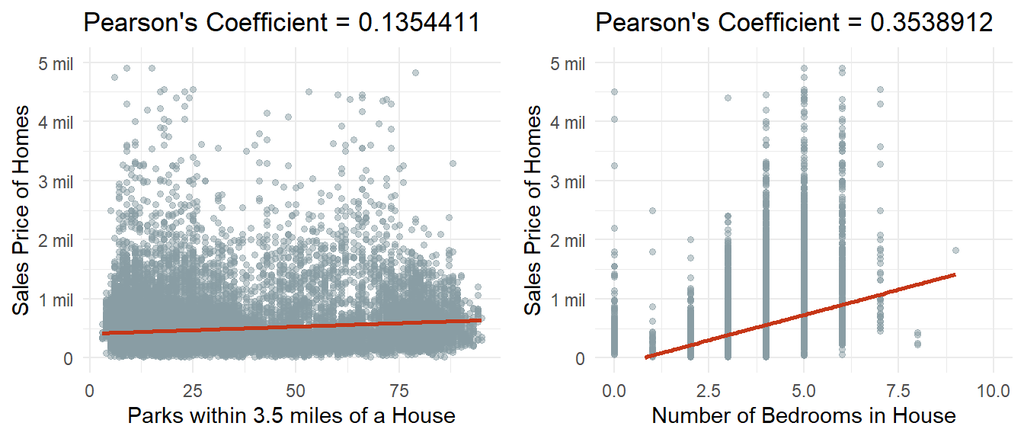

```r
MKLB_scatplo <- subset(MKLB_modelling, price < 5000000)

J <- ggplot(data = MKLB_scatplo, aes(x = ParkBuffer, y = price)) +
  geom_point(size=2, shape=20, color = "#899da4", alpha=0.5)  +
  scale_x_continuous(name="Parks within 3.5 miles of a House")+
  scale_y_continuous(name="Sales Price of Homes",
                     limits = c(0,5000000),
                     breaks = seq(0,5000000, by=1000000),
                     labels = c("0","1 mil","2 mil","3 mil","4 mil", "5 mil")) +
  geom_smooth(method = "lm", se = F, colour = "#c63617",fullrange=T, size=1) +
  labs(title =  "Pearson's Coefficient = 0.1354411")+
  theme_minimal()

K <- ggplot(data = MKLB_scatplo, aes(x = bedrooms, y = price)) +
  geom_point(size=2, shape=20, color = "#899da4", alpha=0.5)  +
  scale_x_continuous(name="Number of Bedrooms in House",
                     limits = c(0,10))+
  scale_y_continuous(name="Sales Price of Homes",
                     limits = c(0,5000000),
                     breaks = seq(0,5000000, by=1000000),
                     labels = c("0","1 mil","2 mil","3 mil","4 mil", "5 mil")) +
  geom_smooth(method = "lm", se = F, colour = "#c63617", size=1) +
  labs(title =  "Pearson's Coefficient = 0.3538912 ")+
  theme_minimal()

L <- ggplot(data = MKLB_scatplo, aes(x = daycare_nn1, y = price)) +
  geom_point(size=2, shape=20, color = "#899da4", alpha=0.5)  +
  scale_x_continuous(name="Closest Day Care Facility")+
  scale_y_continuous(name="Sales Price of Homes",
                     limits = c(0,5000000),
                     breaks = seq(0,5000000, by=1000000),
                     labels = c("0","1 mil","2 mil","3 mil","4 mil", "5 mil")) +
  geom_smooth(method = "lm", se = F, colour = "#c63617", size=1) +
  labs(title =  "Pearson's Coefficient = 0.1266272 ")+
  theme_minimal()

M <- ggplot(data = MKLB_scatplo, aes(x = MedHHInc, y = price)) +
  geom_point(size=2, shape=20, color = "#899da4", alpha=0.5)  +
  scale_x_continuous(name="Median Household Income (2019)")+
  scale_y_continuous(name="Sales Price of Homes",
                     limits = c(0,5000000),
                     breaks = seq(0,5000000, by=1000000),
                     labels = c("0","1 mil","2 mil","3 mil","4 mil", "5 mil")) +
  geom_smooth(method = "lm", se = F, colour = "#c63617", size=1) +
  labs(title =  "Pearson's Coefficient = 0.4996928")+
  theme_minimal()

ggarrange(J,K, nrow = 1, ncol = 2)
```

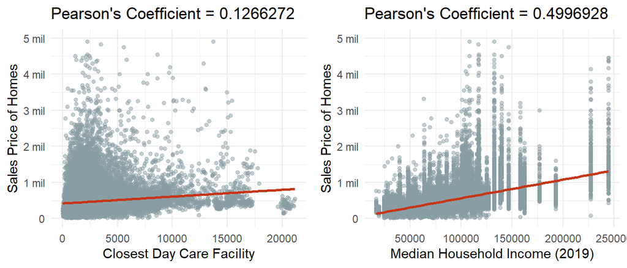

```r
ggarrange(L,M, nrow = 1, ncol = 2)
```

# E. Statistical Modelling

### I. Multivariate Regressions

```r
reg1 <- lm(price ~ ., data =
             MKLB_train %>%
             dplyr::select(price, BldAge, heatedarea, BldStry,Fuel,
                           numfirepla, fullbaths,halfbaths,bedrooms,
                           units, BldGrd, shape_Area, ParkBuffer, BusStopBuffer,
                           ExtWall, totalac, shape_Leng, Lib_nn1,
                           Lib_nn2, Lib_nn3, Lib_nn3,
                           Lib_nn4, Lib_nn5,daycare_nn1, daycare_nn2,
                           daycare_nn3, daycare_nn4, daycare_nn5,
                           TOD, TotalPop, MedHHInc, pctBachelors,
                           School_nn1, School_nn2, School_nn3,
                           School_nn4, School_nn5, WasteBuffer,
                           HUNTERSVILLE, CORNELIUS, DAVIDSON, CHARLOTTE,
                           MINTHILL, MATTHEWS))

reg2 <- lm(price ~ ., data =
             MKLB_train %>%
             dplyr::select(price, BldAge, heatedarea, BldStry,
                           Fuel, numfirepla, fullbaths, halfbaths,
                           bedrooms, units, BldGrd, ParkBuffer,
                           BusStopBuffer,Lib_nn3,  Lib_nn5,
                           daycare_nn2, daycare_nn3,
                           MedHHInc, pctBachelors, School_nn1, School_nn2))

reg3 <- lm(price ~ ., data =
             MKLB_train %>%
             dplyr::select(price, BldAge, heatedarea, BldStry,
                           Fuel, numfirepla, fullbaths, halfbaths,
                           bedrooms, units, BldGrd, ParkBuffer, daycare_nn1,
                           MedHHInc, pctBachelors))

stargazer(reg1, type = "html", style = "aer",
          dep.var.labels=c("Sales Price of Homes"),
          covariate.labels=c("Building Age","Heated Area","Building Storey",
                             "Fuel Used","Fire Places","Full Baths",
                             "Half Baths","Bedrooms","Units","Building Grade",
                             "Area","Parks","Bus Stops","Exterior Wall",
                             "Acreage","Perimeter","Library (KNN1)",
                             "Library (KNN2)","Library (KNN3)","Library (KNN4)",
                             "Library (KNN5)","Daycare (KNN1)",
                             "Daycare (KNN2)","Daycare (KNN3)",
                             "Daycare (KNN4)","Daycare (KNN5)","TOD Zones",
                             "Population","Med Income","Bachelors",
                             "School (KNN1)","School (KNN2)","School (KNN3)",
                             "School (KNN4)","School (KNN5)","Waste Disposal",
                             "Huntersville","Cornelius","Davidson","Charlotte",
                             "Mint Hill","Matthews"),
          title="Results of Regression Model",
          single.row = TRUE,
          notes.label = 'Notes',
          notes = 'Regression model created on the training dataset. The model was selected based on the R-squared statistics, and the number of variables of significance',
          notes.align = 'l')
```

**Results of Regression Model**

|  | Sales Price of Homes |
| --- | --- |
| Building Age | -13,793.420*** (3,932.604) |
| Heated Area | 195.164*** (3.336) |
| Building Storey | -85,293.340*** (4,527.399) |
| Fuel Used | 7,870.941 (19,826.940) |
| Fire Places | 17,484.450*** (4,024.133) |
| Full Baths | 67,869.520*** (3,620.885) |
| Half Baths | 53,865.080*** (4,010.681) |
| Bedrooms | -25,405.340*** (2,207.809) |
| Units | -59,106.400*** (8,758.343) |
| Building Grade | 44,972.020*** (3,008.860) |
| Area | 4.744*** (0.089) |
| Parks | 1,693.510*** (162.540) |
| Bus Stops | 1,722.527** (669.506) |
| Exterior Wall | -1,879.362 (2,108.405) |
| Acreage | -9.326 (13.189) |
| Perimeter | -268.255*** (13.562) |
| Library (KNN1) | -0.508 (0.637) |
| Library (KNN2) | -11.043*** (2.333) |
| Library (KNN3) | 14.410*** (4.243) |
| Library (KNN4) | 26.798*** (3.832) |
| Library (KNN5) | -38.144*** (1.964) |
| Daycare (KNN1) | 0.384 (3.173) |
| Daycare (KNN2) | 21.093*** (7.441) |
| Daycare (KNN3) | -24.649* (13.339) |
| Daycare (KNN4) | -8.108 (17.468) |
| Daycare (KNN5) | 10.087 (9.761) |
| TOD Zones | -13,650.210* (7,883.157) |
| Population | 0.835 (0.980) |
| Med Income | 2.148*** (0.066) |
| Bachelors | -196,383.900 (139,956.700) |
| School (KNN1) | -10.941*** (2.130) |
| School (KNN2) | 35.140*** (4.831) |
| School (KNN3) | -12.954* (7.515) |
| School (KNN4) | -32.766*** (10.208) |
| School (KNN5) | 23.472*** (6.251) |
| Waste Disposal | -7,417.630** (3,625.680) |
| Huntersville | -174,649.800*** (18,087.590) |
| Cornelius | 182,360.000*** (23,752.020) |
| Davidson | 15,164.090 (26,837.720) |
| Charlotte | -86,200.340*** (16,890.260) |
| Mint Hill | -149,075.100*** (19,512.720) |
| Matthews | -177,445.500*** (19,535.710) |
| Constant | 170,155.200*** (48,543.060) |
| Observations | 25,407 |
| R<sup>2</sup> | 0.610 |
| Adjusted R<sup>2</sup> | 0.609 |
| Residual Std. Error | 262,122.100 (df = 25364) |
| F Statistic | 944.398*** (df = 42; 25364) |
| Notes | ***Significant at the 1 percent level. |
|  | **Significant at the 5 percent level. |
|  | *Significant at the 10 percent level. |
|  | Regression model created on the training dataset. The model was selected based on the R-squared statistics, and the number of variables of significance |

### II. Goodness of Fit

We created four new columns in test set, namely predicted sales price (using the training model), the error in sales price, the mean absolute error in sales price, and the absolute percent error in sales price (this is the difference between predicted and observed prices on a percentage basis). We also removed outlier homes with a sales price that was exceedingly high and could potentially skew our model.

Testing for goodness of fit, we can see that the Mean Sales Price of Homes is *$456342.2*. The Mean Average Error is *126202.5*, which is not trivial. The overall Mean Absolute Percentage Error is *25%*, as shown in the table below.

```r
MKLB_test <-
  MKLB_test %>%
  mutate(SalePrice.Predict = predict(reg1, MKLB_test),
         SalePrice.Error = SalePrice.Predict - price,
         SalePrice.AbsError = abs(SalePrice.Predict - price),
         SalePrice.APE = (abs(SalePrice.Predict - price)) / SalePrice.Predict)%>%
  filter(price < 5000000)

MKLB_test.table <- data.frame(NAME='Mecklenberg Test Data Set',
   MAE = mean(na.omit(MKLB_test$SalePrice.AbsError)),
   MAPE = mean(na.omit(MKLB_test$SalePrice.APE)))
MKLB_test.table %>% kable() %>% kable_styling()
```

| NAME | MAE | MAPE |
| --- | --- | --- |
| Mecklenberg Test Data Set | 126202.5 | 0.2501864 |

### III. Cross Validation

The Mean Average Error across each fold is *126875.1*, which is close to our obtained MAE of *126202.5*. This implies that our model would be fairly generalizable across the county, for the purpose of this analysis.

```r
fitControl <- trainControl(method = "cv", number = 100)
set.seed(825)

reg.cv <-
  train(price ~ ., data =
          st_drop_geometry(MKLB_modelling) %>%
          dplyr::select(price, BldAge, heatedarea, BldStry,Fuel,
                        numfirepla, fullbaths, halfbaths,bedrooms, units,
                        BldGrd, shape_Area, ParkBuffer, BusStopBuffer,
                        ExtWall, totalac,shape_Leng,Lib_nn1,
                        Lib_nn2, Lib_nn3, Lib_nn3, Lib_nn4,
                        Lib_nn5,daycare_nn1, daycare_nn2,daycare_nn3,
                        daycare_nn4, daycare_nn5,TOD, TotalPop, MedHHInc,
                        pctBachelors,School_nn1, School_nn2, School_nn3,
                        School_nn4, School_nn5, WasteBuffer,HUNTERSVILLE,
                        CORNELIUS, DAVIDSON, CHARLOTTE,MINTHILL,
                        MATTHEWS, PINEVILLE),
     method = "lm", trControl = fitControl, na.action = na.pass)

MKLB_cross.table <- data.frame(NAME='Cross Validation Data',
   MAE = mean(na.omit(reg.cv$resample$MAE)))
MKLB_cross.table %>% kable() %>% kable_styling()
```

| NAME | MAE |
| --- | --- |
| Cross Validation Data | 126875.1 |

Visualising bar plots of the cross validation MAE histogram, it looks like the errors are generally, in the same approximate range but with a few outliers. In terms of generalizibility, it shows afair amount of generalizability and we believe our model would still be a good option for the purpose of our study.

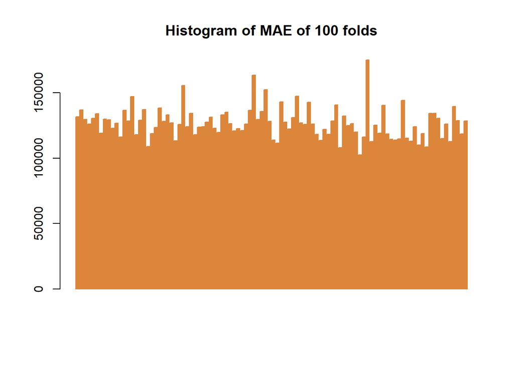

```r
barplot(reg.cv$resample$MAE,col="#dc863b",border="#dc863b",
        main = 'Histogram of MAE of 100 folds')
```

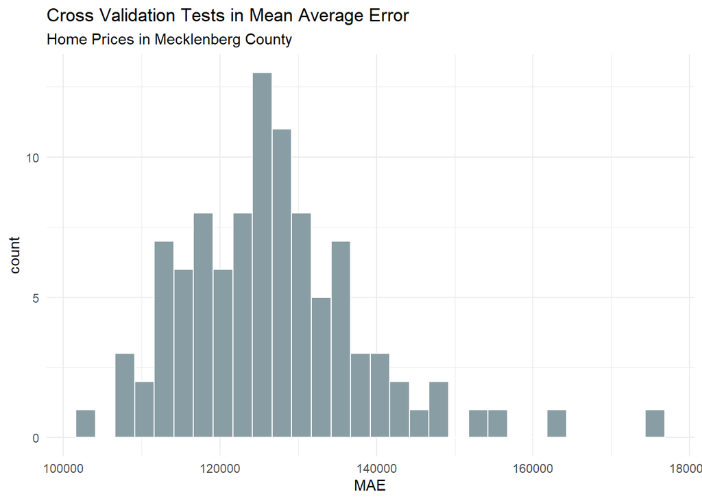

```r
ggplot(reg.cv$resample, aes(x=MAE)) +
  geom_histogram(fill = "#899da4",color="white") +
  labs(title = "Cross Validation Tests in Mean Average Error",
       subtitle="Home Prices in Mecklenberg County") +
  theme_minimal()
```

### III. Visualizing Observations vs. Predictions

To visualize predicted prices as a function of observed prices, we created a scatterplot showing both actual predictions vs. perfect predictions. The **blue line represents a perfection prediction**, while the **red line represents our actual prediction**. When visually comparing predicted vs observed prices, our model appears to do pretty good! The actual predictions only seem to diverge when it comes to predicting very expensive homes.

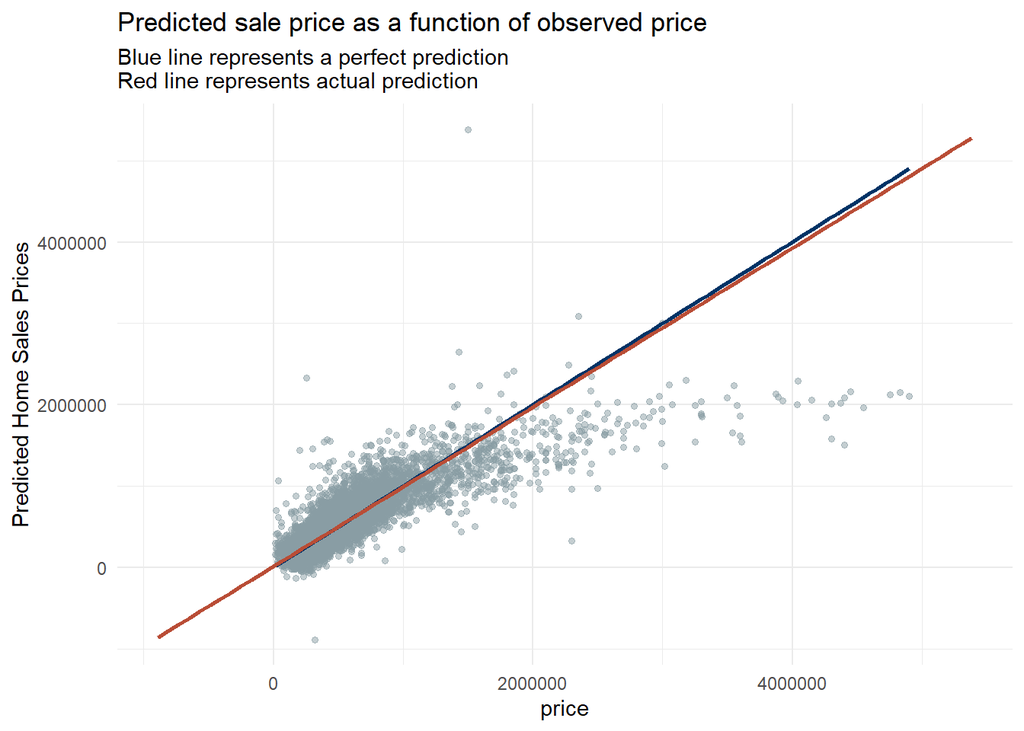

```r
MKLB_test %>%
  dplyr::select(SalePrice.Predict, price) %>%
    ggplot(aes(price, SalePrice.Predict)) +
  geom_point(size=2, shape=20, color = "#899da4", alpha=0.5) +
  stat_smooth(aes(price, price),
             method = "lm", se = FALSE, size = 1, colour="#003366") +
  stat_smooth(aes(SalePrice.Predict, price),
              method = "lm", se = FALSE, size = 1, colour="#b94d36") +
  scale_y_continuous(name="Predicted Home Sales Prices")+
  labs(title="Predicted sale price as a function of observed price",
       subtitle="Blue line represents a perfect prediction \nRed line represents actual prediction") +
  theme_minimal()
```

Pictured below is a map of residuals of for our test set, essentially a map of our errors between predicted and observed home prices.

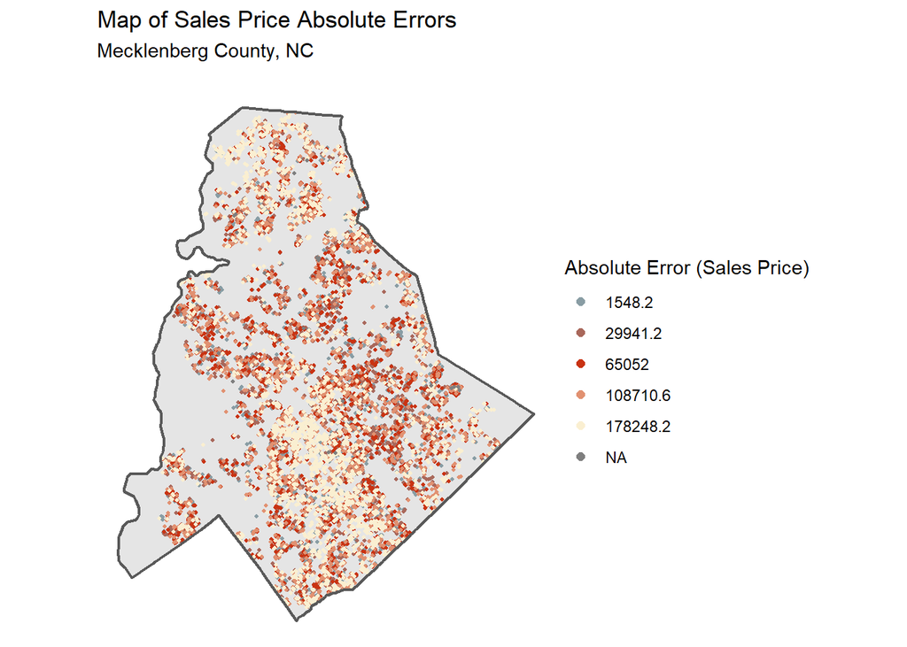

```r
MKLB_test_1<-MKLB_modelling[-MKLB_set,] %>%
  dplyr::select(geometry, lot_num, price,zipcode) %>%
  filter(price < 5000000)

MKLB_test_2 <-MKLB_test %>%
  dplyr::select(SalePrice.Predict, SalePrice.Error, SalePrice.AbsError,
                SalePrice.APE, lot_num, price,zipcode)%>%
  filter(price < 5000000)

MKLB_test_geom <- merge(MKLB_test_1, MKLB_test_2)

ggplot() +
  geom_sf(data=st_union(tracts19), size=0.75) +
  geom_sf(data = MKLB_test_geom, aes(colour = q5(SalePrice.AbsError), size=0.5),
          show.legend = "point", size = .75) +
  geom_sf(data=st_union(tracts19), size=0.75, fill=NA)+
  scale_colour_manual(values = col7,
                   labels=qBr(MKLB_test,"SalePrice.AbsError"),
                   name="Absolute Error (Sales Price)") +
  labs(title="Map of Sales Price Absolute Errors",
       subtitle = "Mecklenberg County, NC\n") +
  theme_void()+
  guides(color = guide_legend(override.aes = list(size = 2)))
```

### IV. Understanding Auto Spatial Correlation

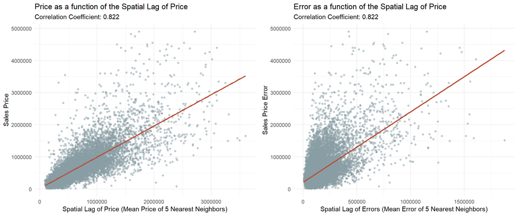

```r
MKLB_modelling1 <-
  MKLB_modelling %>%
  mutate(Regression = "Final Regression",
         SalePrice.Predict = predict(reg1, MKLB_modelling),
         SalePrice.Error = price - SalePrice.Predict,
         SalePrice.AbsError = abs(price - SalePrice.Predict),
         SalePrice.APE = (abs(price - SalePrice.Predict)) / price)%>%
  filter(price < 5000000)

coords <- st_coordinates(MKLB_modelling1)
neighborList <- knn2nb(knearneigh(coords, 5))
spatialWeights <- nb2listw(neighborList, style="W")
MKLB_modelling1$lagPrice <- lag.listw(spatialWeights, MKLB_modelling1$price)

MKLB_modelling1$lagPriceError <- lag.listw(spatialWeights, MKLB_modelling1$SalePrice.AbsError, NAOK = TRUE)

CO <- ggplot(MKLB_modelling1, aes(x=lagPrice, y=price)) +
    geom_point(size=2, shape=20, color = "#899da4", alpha=0.5) +
    geom_smooth(method = "lm", se = FALSE, colour = "#b94d36") +
    labs(title = "Price as a function of the Spatial Lag of Price",
         subtitle = "Correlation Coefficient: 0.822",
         x = "Spatial Lag of Price (Mean Price of 5 Nearest Neighbors)",
         y = "Sales Price") +
    theme_minimal()

DO <- ggplot(MKLB_modelling1, aes(x=lagPriceError, y=price)) +
    geom_point(size=2, shape=20, color = "#899da4", alpha=0.5) +
    geom_smooth(method = "lm", se = FALSE, colour = "#b94d36") +
    labs(title = "Error as a function of the Spatial Lag of Price",
         subtitle = "Correlation Coefficient: 0.822",
         x = "Spatial Lag of Errors (Mean Error of 5 Nearest Neighbors)",
         y = "Sales Price Error") +
  theme_minimal()

ggarrange(CO,DO,align = "v")
```

### V. Morans I Test

The *Moran’s I statistic is 0.32*, which implies some positive spatial autocorrelation, or clustering. Moreover, we have a *p-value around 0.001* suggesting that our model errors cluster more than what we might expect due to random chance alone, again suggesting spatial correlation in our modelling dataset.

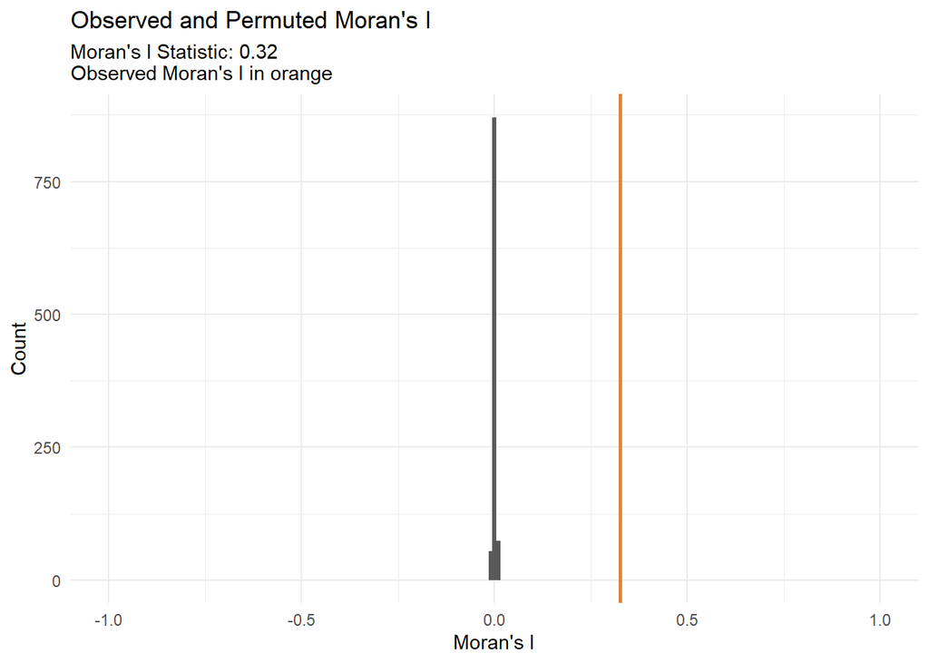

```r
moranTest <- moran.mc(MKLB_modelling1$SalePrice.AbsError,
                      spatialWeights, nsim = 999, na.action = na.exclude)

ggplot(as.data.frame(moranTest$res[c(1:999)]), aes(moranTest$res[c(1:999)])) +
  geom_histogram(binwidth = 0.01) +
  geom_vline(aes(xintercept = moranTest$statistic), colour = "#dc863b",size=1) +
  scale_x_continuous(limits = c(-1, 1)) +
  labs(title="Observed and Permuted Moran's I",
       subtitle= "Moran's I Statistic: 0.32 \nObserved Moran's I in orange",
       x="Moran's I",
       y="Count") +
  theme_minimal()
```

# F. The Predictions

### I. Completing the Challenge

To complete the challenge, we predicted the sales prices for the challenge dataset and then combined it with the main dataframe. The map below shows the sales prices of the completed data frame. It can be observed that a large proportion of higher priced homes are located in the center of the city of Charlotte, as well as to the north of the county.

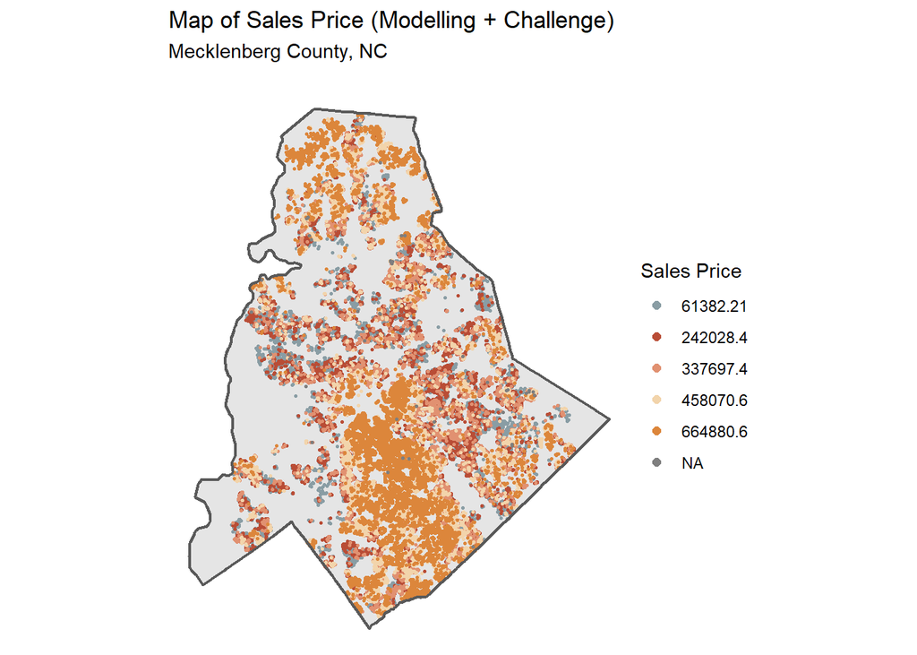

```r
MKLB_challenge1 <- MKLB %>% filter(price==0)

MKLB_challenge1 <-
  MKLB_challenge1 %>%
  mutate(Regression = "Final Regression",
         SalePrice.Predict = predict(reg1, MKLB_challenge1),
         SalePrice.Error = price - SalePrice.Predict,
         SalePrice.AbsError = abs(price - SalePrice.Predict),
         SalePrice.APE = (abs(price - SalePrice.Predict)) / price)%>%
  filter(price < 5000000)

MKLB_modelling1 <- MKLB_modelling1 %>%select(-c(lagPrice, lagPriceError))

To_Predict <- rbind(MKLB_modelling1,MKLB_challenge1)

ggplot()+
  geom_sf(data=st_union(tracts19), size=0.75) +
  geom_sf(data = st_centroid(To_Predict),
          aes(colour=q5(SalePrice.Predict)),size=0.5,
          show.legend = "point", size = .75)+
  geom_sf(data=st_union(tracts19), size=0.75, fill=NA)+
  scale_color_manual(values = col5,
                   labels=qBr(st_centroid(To_Predict),"SalePrice.Predict"),
                   name="Sales Price")+
  labs(title="Map of Sales Price (Modelling + Challenge)",
       subtitle = "Mecklenberg County, NC\n") +
  theme_void()+
  guides(color = guide_legend(override.aes = list(size = 2)))
```

# G. Understanding Neighborhood Fixed Effects

### I. MAPE by Neighborhood

We can see that there are rich homes skewing data- as we plot the mean average percent error (MAPE) as a function of price, homes with low sales prices have high errors. This implies that our model predicts well for certain areas, namely those in higher income neighborhoods.

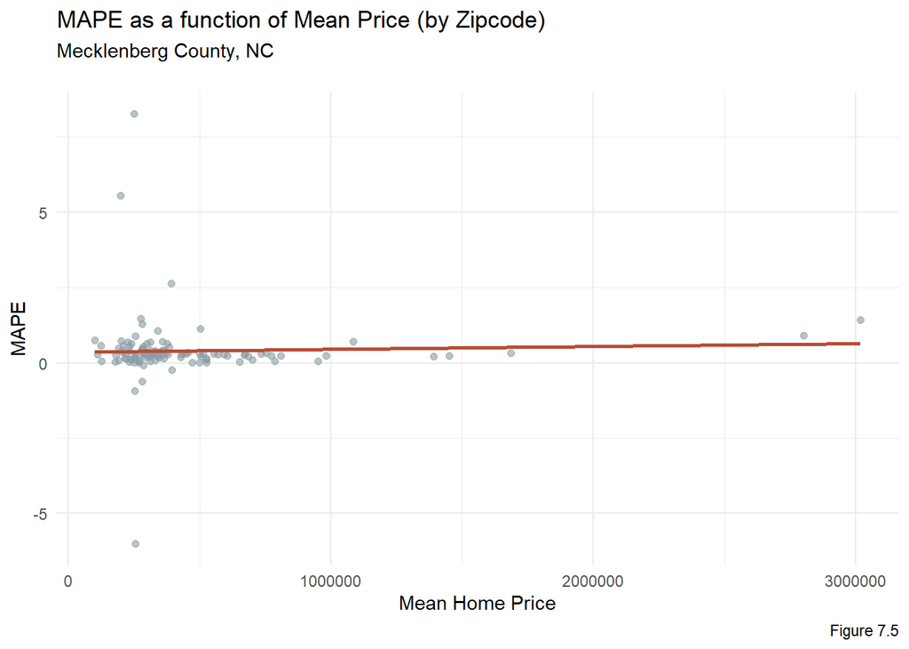

```r
Zip_Summary <- MKLB_test %>%
    group_by(zipcode) %>%
    summarize(meanPrice = mean(price, na.rm = T),
       meanPredict = mean(SalePrice.Predict, na.rm = T),
       meanPriceError = mean(SalePrice.Error, na.rm = T),
       meanPriceAbsError = mean(SalePrice.AbsError, na.rm = T),
       meanPriceAPE = mean(SalePrice.APE, na.rm = T))

ggplot(Zip_Summary) +
  geom_point(aes(meanPrice, meanPriceAPE),size=2.5, shape=20,
             color = "#899da4", alpha=0.6) +
  geom_smooth(method = "lm", aes(meanPrice, meanPriceAPE),
              se = FALSE, colour = "#b94d36")+
  labs(title = "MAPE as a function of Mean Price (by Zipcode)",
       subtitle = "Mecklenberg County, NC\n",
       x = "Mean Home Price", y = "MAPE",
       caption = "Figure 7.5") +
  theme_minimal()
```

Taking a look at the **MAPE as a function of Mean Price scatterplot**: Generally this looks good, there is a very low error by mean home price across most zipcodes, but there are a couple of low price homes that seem to have very high errors when predicting their sale price. Given the map below, these homes seem likely to be located in areas of low income.

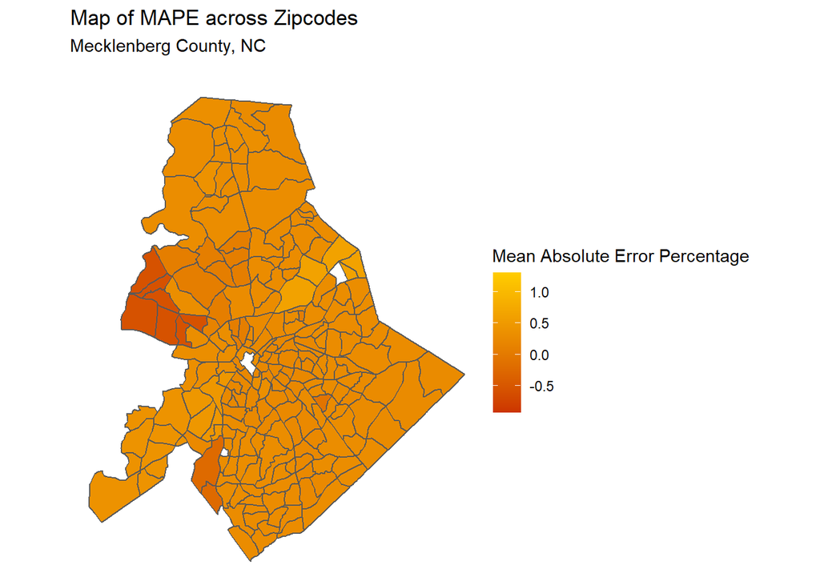

```r
MKLB_test_geom <- MKLB_test_geom %>%
  group_by(zipcode)%>%
  dplyr::mutate(meanMAPE = mean(SalePrice.APE, na.rm = T)) %>%
  st_transform(st_crs(tracts19))

MKLB_neigh <- st_join(tracts19,MKLB_test_geom) %>%
  filter(meanMAPE > -0.94 & meanMAPE <= 1.4)

ggplot() +
  geom_sf(data = MKLB_neigh, aes(fill=(meanMAPE))) +
  scale_fill_gradient(low = "#cc3300",high = "#ffcc00",na.value = NA,
                   name="Mean Absolute Error Percentage") +
  labs(title="Map of MAPE across Zipcodes",
       subtitle = "Mecklenberg County, NC\n") +
  theme_void()+
  guides(color = guide_legend(override.aes = list(size = 2)))
```

*Note*: We chose to not show the points denoting homes on the map, becuase the sheer number of points made it very difficult to view the MAPE color gradient beneath it.

### II. Variables from the Census

Using `tidycensus`, we split the model into two- based on race and income to observe the spatial variations in price based on these variables.

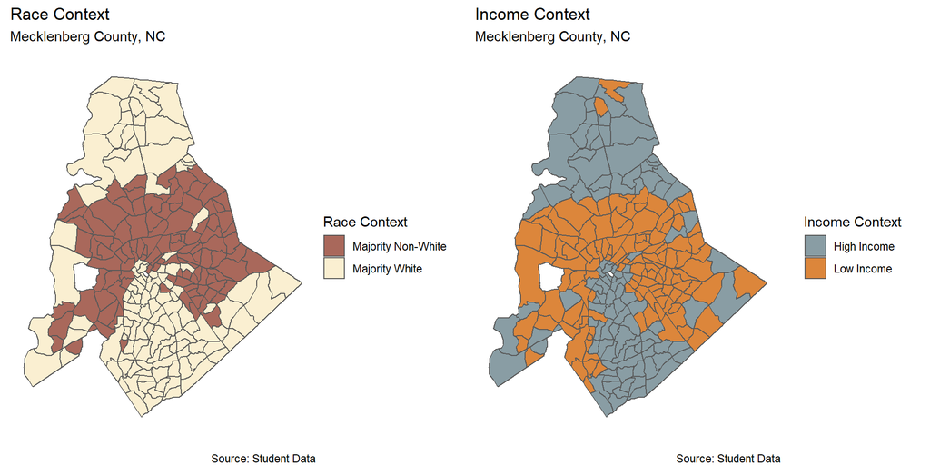

```r
tracts19_A <-
  get_acs(geography = "tract", variables = c("B01001_001E","B01001A_001E","B06011_001E"),
          year = 2019, state=37, county=119, geometry=T, output = "wide") %>%
  st_transform('EPSG:2264')  %>%
  rename(TotalPop = B01001_001E,
         NumberWhites = B01001A_001E,
         Median_Income = B06011_001E) %>%
  mutate(percentWhite = NumberWhites / TotalPop,
         raceContext = ifelse(percentWhite > .5, "Majority White", "Majority Non-White"),
         incomeContext = ifelse(Median_Income > 38437, "High Income", "Low Income"))

Y <- ggplot() + geom_sf(data = na.omit(tracts19_A), aes(fill = raceContext)) +
    scale_fill_manual(values = c("#a9685b", "#faefd1"), name="Race Context") +
    labs(title = "Race Context",
         subtitle = "Mecklenberg County, NC\n",
         caption = "\nSource: Student Data") +
    theme_void()

Z <- ggplot() + geom_sf(data = na.omit(tracts19_A), aes(fill = incomeContext)) +
    scale_fill_manual(values = c("#899da4", "#dc863b"), name="Income Context") +
    labs(title = "Income Context",
         subtitle = "Mecklenberg County, NC\n",
         caption = "\nSource: Student Data") +
    theme_void()

ggarrange(Y,Z, align = "v")
```

Comparing the maps above with our tables- our model appears biased, given that it works better on predicting sales prices in zipcodes where there is a majority white population. The higher *35% MAPE* for majority non-white, suggests our model doesn’t generalize well across these neigborhoods.

Taking a look at the income related variations- the *MAPE is 28% for high-income* and *36% for lower-income*. This implies that **our model does better at predicting house sale prices in high income areas**. This is an expected observation given that the previous maps show that race and income are related.

```r
MKLB_neigh <- st_join(MKLB_modelling1, tracts19_A) %>%
  group_by(raceContext) %>%
  summarise(mean.MAPE = scales::percent(mean(SalePrice.APE, na.rm = T))) %>%
  st_drop_geometry() %>%
  spread(raceContext, mean.MAPE)%>%
  select(-c(3))
MKLB_neigh %>% kable() %>% kable_styling()
```

| Majority Non-White | Majority White |
| --- | --- |
| 35% | 29% |

```r
MKLB_neigh1 <- st_join(MKLB_modelling1, tracts19_A) %>%
  group_by(incomeContext) %>%
  summarise(mean.MAPE = scales::percent(mean(SalePrice.APE, na.rm = T))) %>%
  st_drop_geometry() %>%
  spread(incomeContext, mean.MAPE)%>%
  select(-c(3))
MKLB_neigh1 %>% kable() %>% kable_styling()
```

| High Income | Low Income |
| --- | --- |
| 28% | 36% |

# H. Discussions

Overall, this model is a good place to start building upon. Despite the fair amount of generalizability, we do not think this is an effective model as it does not do well when it comes to predicting home prices in low-income, predominately non-white neighborhoods. This is an important especially when taking the racial and income discrepancies all over the country. Our model does have the potential to be better fitted, provided we take more demographic and spatial variables into consideration. Places of work, commute times, grocery stores and even nearby water bodies have an effect on sales prices.

Some of the more interesting variables in our study were the presence of parks and public open spaces around homes. Publicly accessible green space has become an important part of residential living- particularly after the pandemic, so it was interesting to look at how this spatial variable affected sales price. To touch briefly on the prediction error- our model had an error of 25%, and was able to predict home sales prices in high income neighborhoods fairly well. As mentioned previously, the lack of more information (both economic and demographic), meant that our model predicted poorly in certain regions of the county.

# I. Conclusions

- Pulling from ACS, housing, and open data we created a model to predict sales prices in Mecklenberg County, NC
- We observed a low error of *25%* in our model (this is the difference between predicted and observed prices). With this low value we can say that our model is pretty accurate!)
- The model generalizes fairly well, but **does better at predicting house sale prices in high income areas**, indicating a bias
- Geographical location also seems to have an effect on our model, i.e model works better in high income tracts (closer to the urban center and to the north of the county), and poorly in low-income tracts.
- We would recommend our model to Zillow, but with a caveat that it should not be used on areas of low income (e.g. areas with income < 38437) because the error is much too high to be useful.
- We could improve this model by adding spatial variables like proximity to hospitals, shopping centers and cafes, as well as looking at demographical variables like age and rate of household formation.